# COVID19 á Íslandi

Spálíkan fyrir fjölda tilfella og álag á heilbrigðisþjónustu

2020-03-26

# Samantekt

Spáin hefur breyst frá því 22. mars enda hafa færri smit greinst síðustu daga.

Greiningarvinnan mun halda áfram og spálíkanið verður uppfært reglulega með nýjum upplýsingum. Hafa ber í huga að vegna fámennis geta tölurnar um fjölda greindra tilfella breyst mikið frá degi til dags sem hefur áhrif á niðurstöður spálíkansins. Líkanið verður þó stöðugra eftir því sem á líður.

# Aðferðir og forsendur spálíkans

- Við notuðum logistískt vaxtarlíkan með Poisson dreifingu á fjölda þegar greindra smita á Íslandi til að gera forspá um miðgildi (líklegustu spá) og 97,5% efri mörk (svartsýnustu spá) um uppsafnaðan fjölda greindra COVID-19 tilfella á Íslandi og virkra greindra tilfella (þar sem gert er ráð fyrir 21 veikindadegi) á næstu vikum.
- Í samræmi við þekkingu á faraldsfræði smitsjúkdóma, þá gerir spálíkanið ráð fyrir að það hægi á núverandi veldisvexti greindra tilfella þar til að hann stöðvist á einhverjum tímapunkti, þar sem faraldurinn nær hámarki og virkum smitum fækkar þar á eftir.
- Reikniaðferðin sem notuð er til að meta lögun vaxtarferilsins á Íslandi tekur mið af upplýsingum um COVID-19 faraldursferla í öðrum löndum (sjá viðauka) til að áætla mögulega lögun ferlisins á Ísland. Lönd sem eru komin lengra í ferlinum, t.d. Suður-Kórea, vega meira en þau sem styttra eru komin.
- Þar sem allir smitaðir einstaklingar á Íslandi eru skjólstæðingar íslensks heilbrigðiskerfis, þá byggir spáin á heildarfjölda smitaðra einstaklinga á Íslandi óháð uppruna smita, hvort einstaklingar greinist í sóttkví eða ekki, gegnum skimun Heilsugæslunnar eða ÍE. Hafa skal í huga að smitaðir einstaklingar í sóttkví gætu mögulega bætt minna við veldisvöxtinn en aðrir einstaklingar.
- Við notuðum fyrirliggjandi aldursdreifingu smita á Íslandi til að áætla skiptingu framtíðartilfella í aldurshópa. Síðan notuðum við upplýsingar frá Ferguson og félögum hjá Imperial College (Tafla 1) um aldurstengd hlutföll spítalainnlagna í forspá okkar um fjölda sjúklinga hérlendis sem gætu lagst inn á spítala og/eða gjörgæslu.
- Hafa ber í huga að aldursdreifing smitaðra einstaklinga á Íslandi er hagstæð enn sem komið er. Ef fjöldi smita eykst meðal aldraðra einstaklinga mun það hafa veruleg áhrif á spálíkanið í átt að auknu álagi á heilbrigðiskerfið.
- Allan kóða á finna á [eftirfarandi vefsíðu](https://github.com/bgautijonsson/covid19).
- Tæknilega skýrslu um aðferð við þróun líkans [má finna hér](https://rpubs.com/bgautijonsson/588811).
- Mælaborð sem heldur utan um þróun COVID-19 á Íslandi og annars staðar má nálgast á [vef Háskóla Íslands hér](https://covid.rhi.hi.is/shiny/dashboard/).

# Niðurstöður

## Greind smit

### Uppsöfnuð greind smit

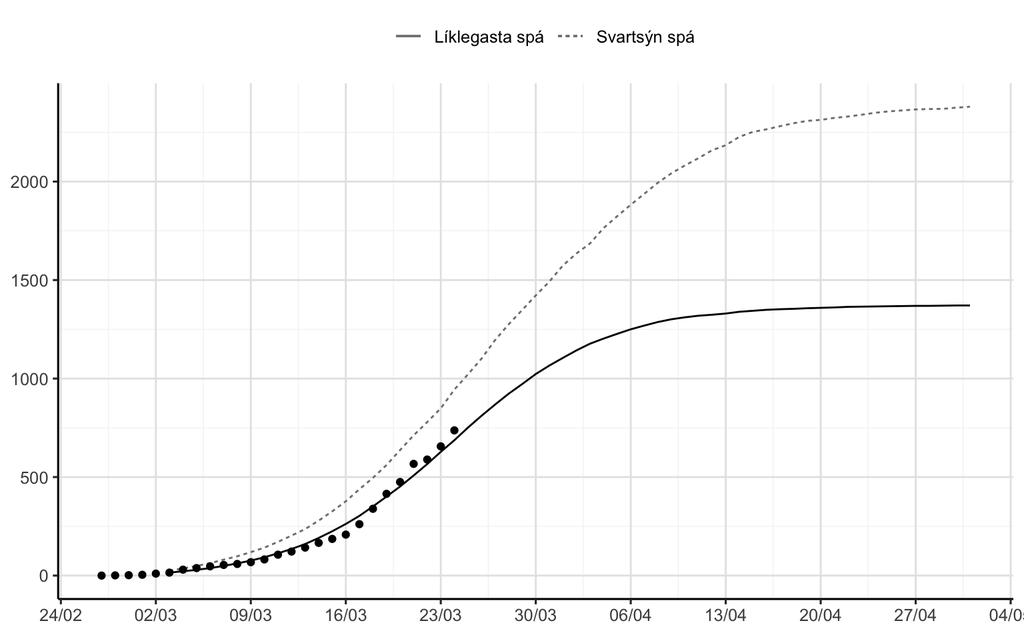

### Virk greind smit á hverjum degi

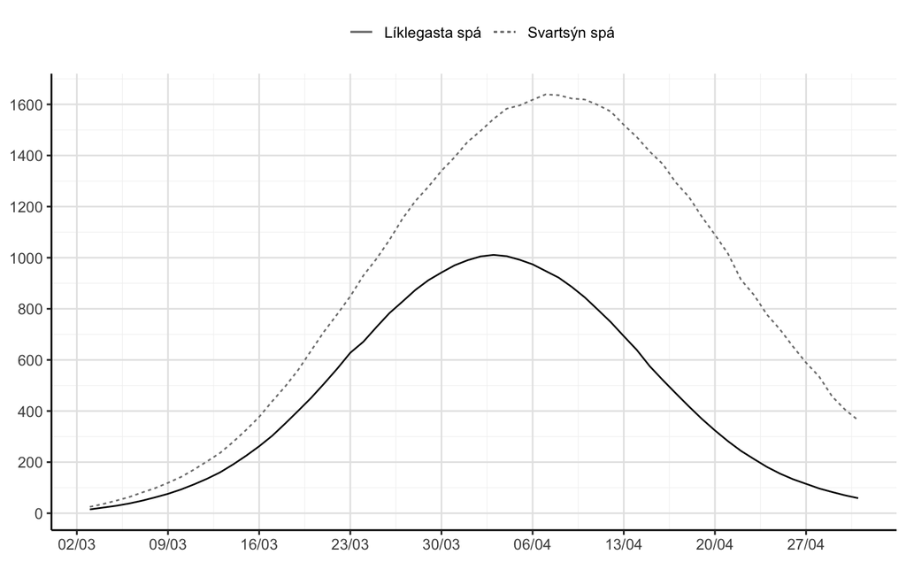

## Sjúkrahúslegur

### Uppsafnaðar sjúkrahúslegur

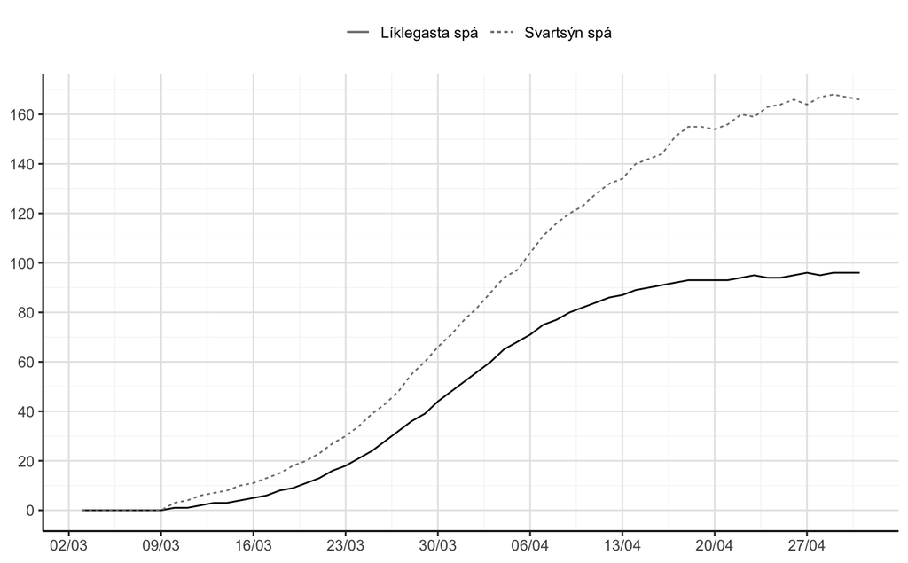

### Virkar sjúkrahúslegur á hverjum degi

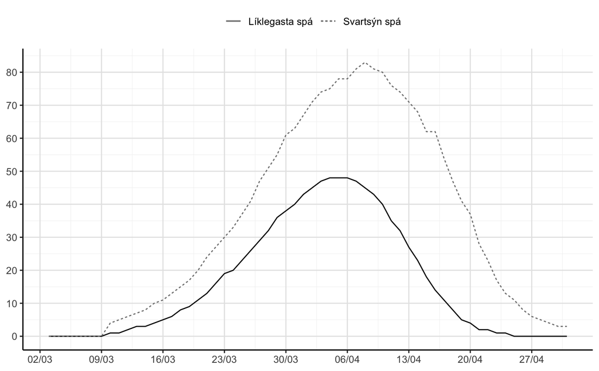

## Gjörgæsla

### Uppsafnaðar gjörgæslulegur

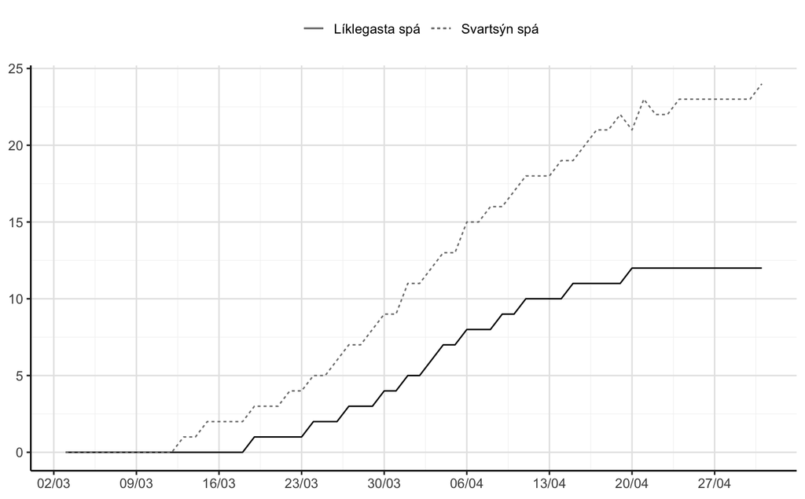

### Virkar gjörgæslulegur á hverjum degi

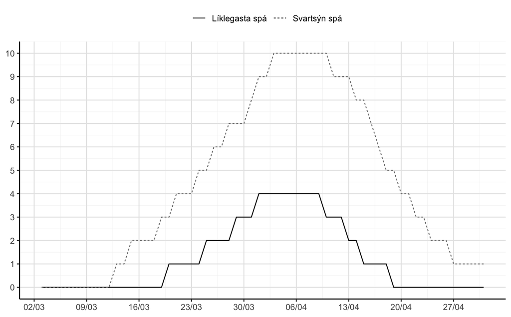

## Aldursskipt

### Greind smit

#### Uppsöfnuð

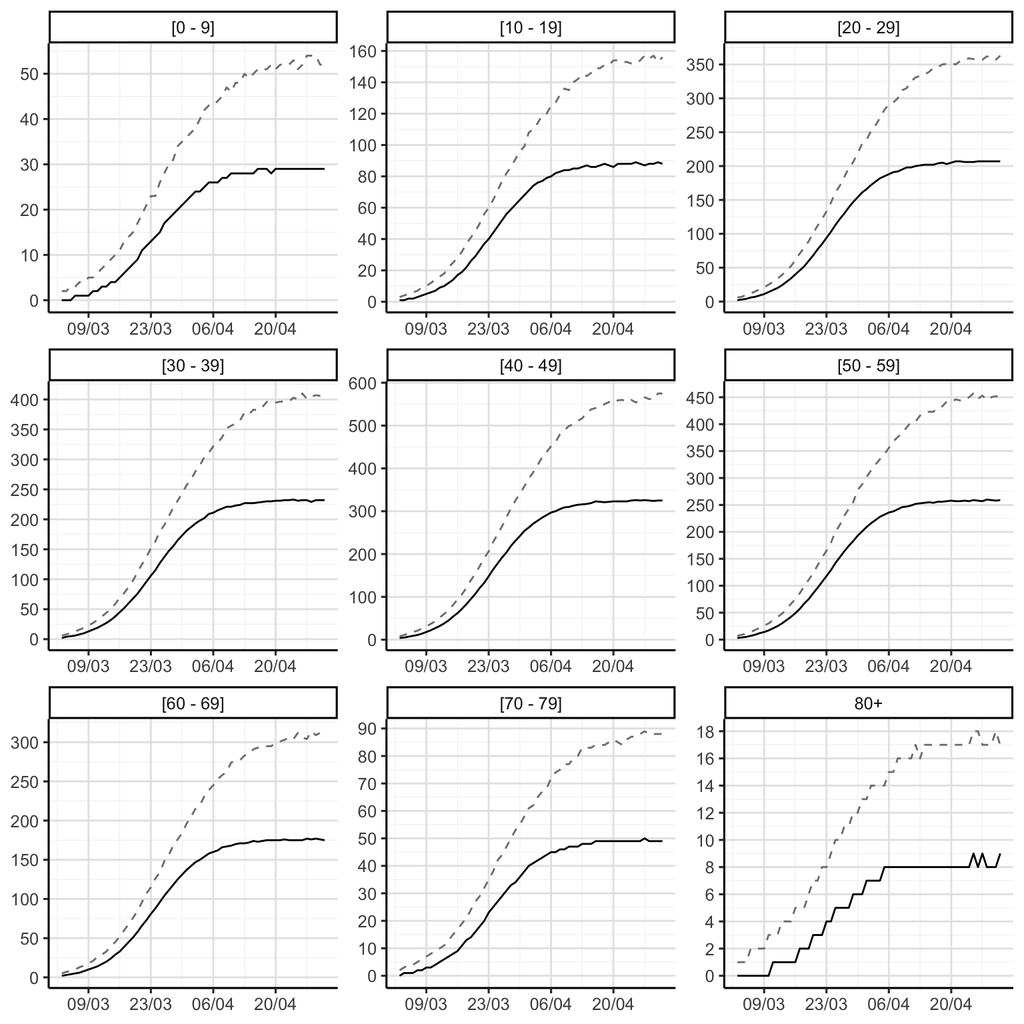

#### Virk

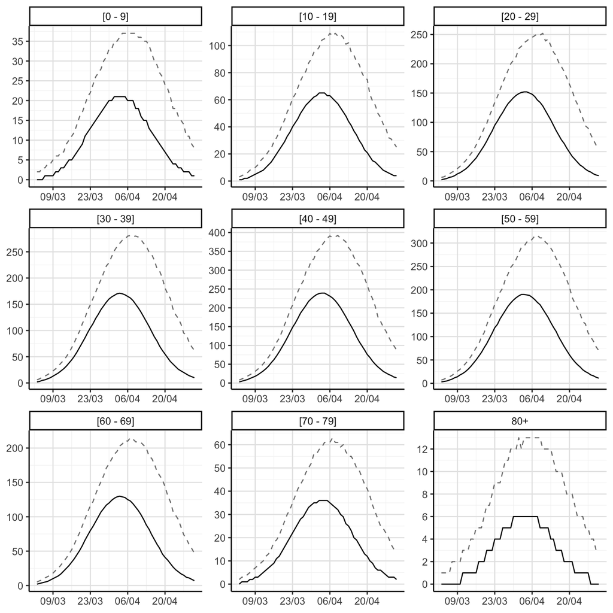

### Sjúkrahúslegur

#### Uppsafnaðar

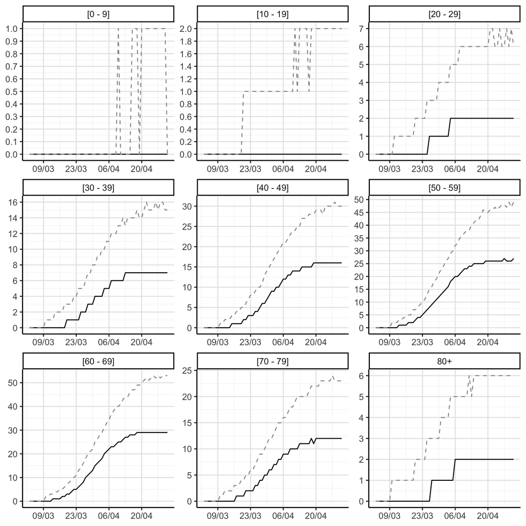

#### Virkar

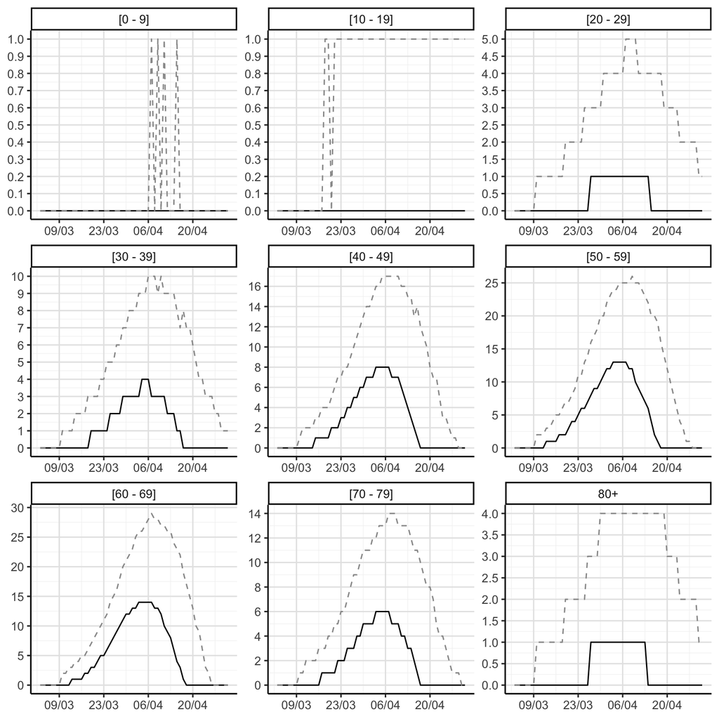

### Gjörgæslulegur

#### Uppsafnaðar

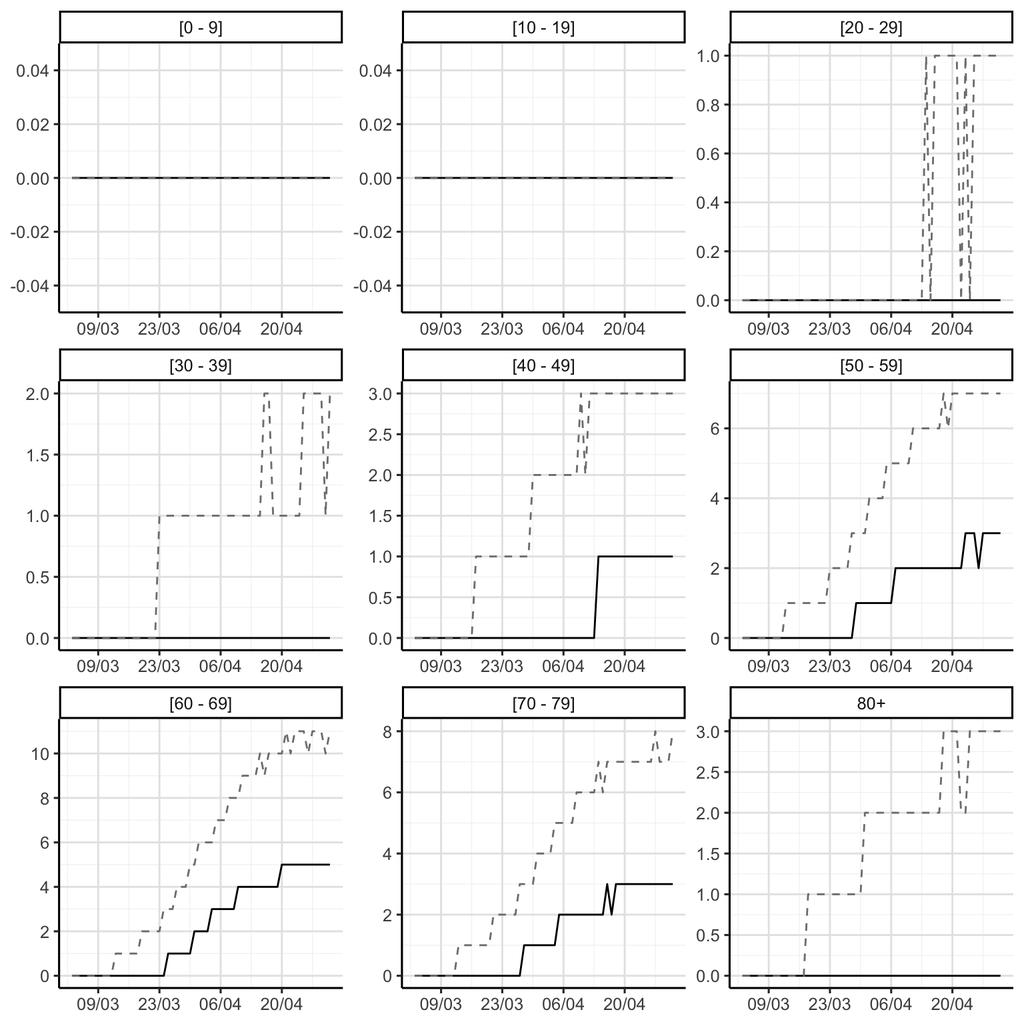

#### Virkar

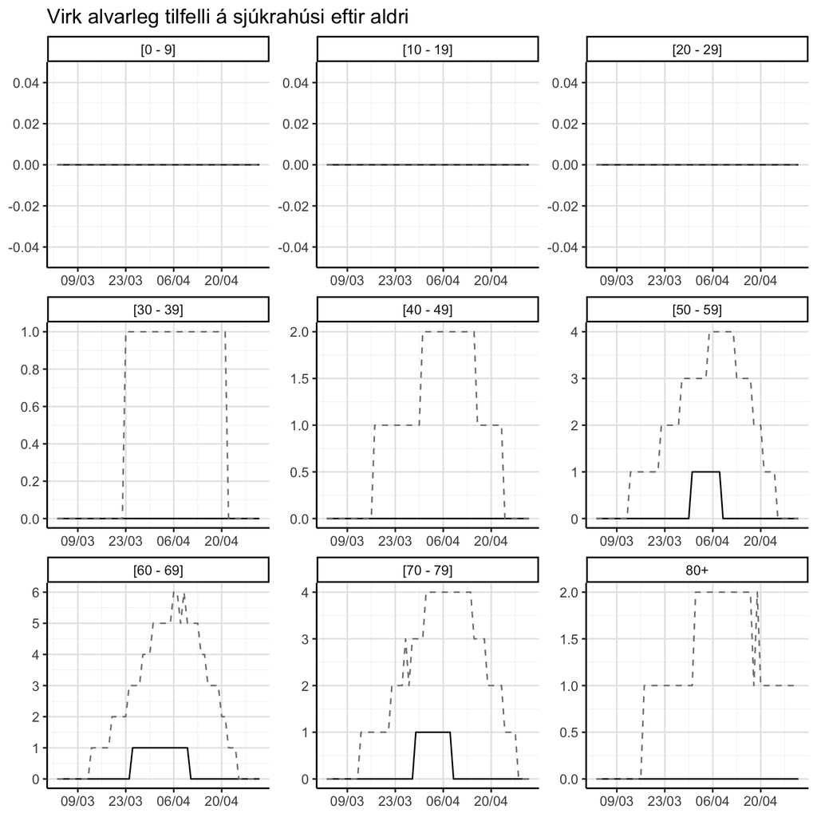

# Viðauki

## Upplýsingar um gögn í líkanasmíð

| Land | Fyrsta athugun | Fjöldi daga | Tíðni Upphaf | Tíðni Nú |
| --- | --- | --- | --- | --- |
| Albania | 2020-03-19 | 7 | 0.0204796 | 0.0426947 |
| Andorra | 2020-03-14 | 11 | 0.0259262 | 2.1259495 |
| Armenia | 2020-03-18 | 8 | 0.0263716 | 0.0895957 |
| Australia | 2020-03-19 | 7 | 0.0224178 | 0.0961386 |
| Austria | 2020-03-11 | 15 | 0.0203236 | 0.5898314 |
| Bahrain | 2020-02-27 | 27 | 0.0201076 | 0.2376351 |
| Barbados | 2020-03-21 | 5 | 0.0209041 | 0.0627123 |
| Belgium | 2020-03-10 | 16 | 0.0207118 | 0.3699522 |
| Bermuda | 2020-03-20 | 6 | 0.0319969 | 0.0959908 |
| Cayman Islands | 2020-03-21 | 5 | 0.0461908 | 0.0461908 |
| Chile | 2020-03-21 | 5 | 0.0228999 | 0.0486491 |
| Costa Rica | 2020-03-21 | 5 | 0.0223870 | 0.0350664 |
| Croatia | 2020-03-20 | 6 | 0.0251797 | 0.0924871 |
| Cyprus | 2020-03-16 | 10 | 0.0254334 | 0.1051247 |
| Czech Republic | 2020-03-15 | 11 | 0.0200202 | 0.1304119 |
| Denmark | 2020-03-11 | 15 | 0.0457390 | 0.2756469 |
| Ecuador | 2020-03-21 | 5 | 0.0245199 | 0.0622782 |
| Estonia | 2020-03-13 | 13 | 0.0203674 | 0.2783544 |
| Finland | 2020-03-13 | 12 | 0.0280180 | 0.1431630 |
| France | 2020-03-10 | 16 | 0.0216798 | 0.3424243 |
| French Polynesia | 2020-03-21 | 5 | 0.0537082 | 0.0895137 |
| Germany | 2020-03-13 | 13 | 0.0283655 | 0.3778151 |
| Greece | 2020-03-15 | 11 | 0.0217693 | 0.0709413 |
| Greenland | 2020-03-20 | 6 | 0.0352908 | 0.0705816 |
| Iceland | 2020-03-02 | 24 | 0.0294958 | 2.3655654 |
| Iran | 2020-03-04 | 22 | 0.0281738 | 0.2992381 |
| Ireland | 2020-03-15 | 11 | 0.0264209 | 0.2721969 |
| Israel | 2020-03-15 | 11 | 0.0208935 | 0.2265424 |
| Italy | 2020-03-02 | 24 | 0.0278943 | 1.1424594 |
| Kuwait | 2020-03-14 | 12 | 0.0237694 | 0.0453996 |
| Latvia | 2020-03-18 | 8 | 0.0319917 | 0.1033175 |
| Lebanon | 2020-03-20 | 6 | 0.0217337 | 0.0443426 |
| Liechtenstein | 2020-03-05 | 15 | 0.0263026 | 1.2362240 |
| Lithuania | 2020-03-21 | 5 | 0.0250034 | 0.0757349 |
| Luxembourg | 2020-03-13 | 12 | 0.0422264 | 1.7848761 |
| Malaysia | 2020-03-18 | 8 | 0.0210643 | 0.0508298 |
| Maldives | 2020-03-16 | 10 | 0.0244843 | 0.0244843 |
| Malta | 2020-03-13 | 13 | 0.0204373 | 0.2724969 |
| Monaco | 2020-02-29 | 14 | 0.0256647 | 0.6929473 |
| Montenegro | 2020-03-20 | 6 | 0.0207011 | 0.0748423 |
| Netherlands | 2020-03-11 | 15 | 0.0223429 | 0.3252008 |
| North Macedonia | 2020-03-19 | 7 | 0.0201588 | 0.0710357 |
| Norway | 2020-03-07 | 19 | 0.0210082 | 0.4770530 |
| Panama | 2020-03-18 | 8 | 0.0202523 | 0.1043227 |
| Portugal | 2020-03-16 | 10 | 0.0239581 | 0.2309756 |
| San Marino | 2020-02-28 | 26 | 0.0295334 | 5.5227407 |
| Seychelles | 2020-03-15 | 11 | 0.0204627 | 0.0716193 |
| Singapore | 2020-03-06 | 20 | 0.0201573 | 0.0961350 |
| Slovakia | 2020-03-20 | 6 | 0.0225398 | 0.0373831 |
| Slovenia | 2020-03-12 | 14 | 0.0274216 | 0.2309187 |
| South Korea | 2020-02-26 | 29 | 0.0223718 | 0.1783689 |
| Spain | 2020-03-10 | 16 | 0.0257613 | 0.8488604 |
| Sweden | 2020-03-09 | 17 | 0.0202264 | 0.2263765 |
| Switzerland | 2020-03-07 | 19 | 0.0243268 | 1.0230039 |
| United Kingdom | 2020-03-16 | 10 | 0.0205982 | 0.1196058 |
| United States | 2020-03-19 | 7 | 0.0286114 | 0.1678423 |
| Uruguay | 2020-03-19 | 7 | 0.0228209 | 0.0545969 |